# fullpythonrevise

VARIABLE IN PYTHON

```python
x = 10
```

```python
x = 'ashu'
```

```python
x = 3.14
```

```python
x = True
```

DATA TYPES IN PYTHON

--> NUMERIC DATATYPES

```python
a = 5
```

```python
b = 3.14
```

```python
c = 2+3j
```

SEQUENCE TYPES

```python
fruits = ['apple','banana','cherry'] #list
```

```python
number = (1,2,3) #tuple
```

```python
range(0,5) #sequence of ranges
```

```
range(0, 5)
```

MAPPING TYPE

```python
student = {'name':'ashu','age':'22'}
```

SET TYPES

```python
set = {1,2,3,3,4,5}
set
```

```
{1, 2, 3, 4, 5}
```

```python
a = 1
type(a)
```

```
int
```

```python
float(a)
type(a)
```

```
int
```

```python
type(a)
```

```
int
```

```python
str(a)
```

```
'1'
```

```python
list1 = [1,2,3,4,5]
tuple(list1)
```

```
(1, 2, 3, 4, 5)
```

```python
type(list1)
```

```
list
```

```python
t1 = (1, 2, 3, 4, 5)
```

```python
list(t1)
```

```
[1, 2, 3, 4, 5]
```

```python
t1 = (1, 2, 3, 4, 5)
```

OPERATORS IN PYTHON

ARITHMETIC OPERATORS

```python
a = 10
b = 3

print(a+b)
print(a-b)
print(a*b)
print(a/b)
print(a//b)
print(a%b)
print(a**b)
```

```
13
7
30
3.3333333333333335
3
1
1000
```

COMPARISON OPERATOR/RELATIONAL OPERATOR

```python
x = 5
y = 10
print(x==y)
print(x!=y)
print(x>y)
print(x<y)
```

```
False
True
False
True
```

LOGICAL OPERATOR

```python
a = True
b = False
print(a and b)
print(a or b)
print(not a)
c = (not a )
print(c)
```

```
False
True
False
False
```

ASSIGNMENT OPERATORS

```python
x = 10
x += 5
print(x)
```

```
15
```

```python
x -= 3
x
```

```
12
```

```python
x *= 2
x
```

```
24
```

```python
x /= 4
x
```

```
6.0
```

```python
x //= 2
x
```

```
3.0
```

```python
x %= 2
x
```

```
1.0
```

```python
x **= 3
x
```

```
1.0
```

BITWISE OPERATOR

```python
a = 6
b = 3
print(a&b)
print(a|b)
print(a^b)
print(~a)
print(a<<2)
print(a>>2)
```

```
2
7
5
-7
24
1
```

IDENTITY OPERATOR

```python
x = [1,2,3]
y = [1,2,3]
z = x

print(x is y)
print(x is not y)
print(x is z)
```

```
False
True
True
```

MEMBERSHIP OPERATORS

```python
fruits = ['apple','banana','cherry']
print('apple' in fruits)
print('mango' in fruits)
print('grapes' not in fruits)
```

```
True
False
True
```

DATA STRUCTURES IN PYTHON

LIST

```python
fruits = ['apple','banana','cherry']
```

```python
fruits.append('grapes')
print(fruits)
```

```
['apple', 'banana', 'cherry', 'grapes']
```

```python
fruits.insert(1,'berry')
```

```python
fruits
```

```
['apple', 'berry', 'banana', 'cherry', 'grapes']
```

```python
f1 = ['papaya','oranges','mangoes']
fruits.extend(f1)
```

```python
fruits
```

```
['apple',
 'berry',
 'banana',
 'cherry',
 'grapes',
 'papaya',
 'oranges',
 'mangoes']
```

REMOVING ELEMENTS FROM THE LIST

```python
fruits.remove('mangoes')
fruits
```

```
['apple', 'berry', 'banana', 'cherry', 'grapes', 'papaya', 'oranges']
```

```python
fruits.pop()
fruits
```

```
['apple', 'berry', 'banana', 'cherry', 'grapes', 'papaya']
```

```python
fruits.clear()
```

```python
fruits
```

```
[]
```

```python
l1 = ['a','b','c','d','e','f','a','a']
l1.index('c')
```

```
2
```

```python
l1.count('a')
```

```
3
```

```python
l2 = [3,4,2,3,5,2,3,5,6,7,8,34,6]
l2.sort()
l2
```

```
[2, 2, 3, 3, 3, 4, 5, 5, 6, 6, 7, 8, 34]
```

```python
l2 = [3,4,2,3,5,2,3,5,6,7,8,34,6]
l2.reverse()
l2
```

```
[6, 34, 8, 7, 6, 5, 3, 2, 5, 3, 2, 4, 3]
```

```python
l3 = l2.copy()
```

```python
l3
```

```
[6, 34, 8, 7, 6, 5, 3, 2, 5, 3, 2, 4, 3]
```

```python
max(l3)
min(l3)
sum(l3)
sorted(l3)
```

```
[2, 2, 3, 3, 3, 4, 5, 5, 6, 6, 7, 8, 34]
```

```python
max(l3)
```

```
34
```

```python
min(l3)
```

```
2
```

```python
sum(l3)
```

```
88
```

```python
sorted(l3)
```

```
[2, 2, 3, 3, 3, 4, 5, 5, 6, 6, 7, 8, 34]
```

LIST SLICING

```python
l3[:]
```

```
[6, 34, 8, 7, 6, 5, 3, 2, 5, 3, 2, 4, 3]
```

```python
l3[0:]
```

```
[6, 34, 8, 7, 6, 5, 3, 2, 5, 3, 2, 4, 3]
```

```python
l3[9]
```

```
3
```

```python
l3[::-1]
```

```
[3, 4, 2, 3, 5, 2, 3, 5, 6, 7, 8, 34, 6]
```

```python
l3[::-2]
```

```
[3, 2, 5, 3, 6, 8, 6]
```

```python
l3[::-3]
```

```
[3, 3, 3, 7, 6]
```

```python
l3[3:7]
```

```
[7, 6, 5, 3]
```

```python
l3[:-6]
```

```
[6, 34, 8, 7, 6, 5, 3]
```

```python
l3[-4:]
```

```
[3, 2, 4, 3]
```

```python
l3[:4]
```

```
[6, 34, 8, 7]
```

TUPLES IN PYTHON

```python
#CREATING TUPLES
t1 = (1,2,3)                #int tuple
t2 = ('apple','banana')     #string tuple
t3 = (1,'hello',3.5,True)   #tuple with mixed data types
```

```python
t = (10,20,30,40,50)
print(t[0])                #ACCESSING ELEMENTS
print(t[-1])
print(t[1:3])
```

```
10
50
(20, 30)
```

```python
tp = (1,2,4,5,1,4,5,2,1)
```

```python
tp.count(1)
```

```
3
```

```python
tp.index(4)
```

```
2
```

TUPLE OPERATIONS

```python
print(t1+t2) #concatenate
```

```
(1, 2, 3, 'apple', 'banana')
```

```python
print(t1*3) #repetition
```

```
(1, 2, 3, 1, 2, 3, 1, 2, 3)
```

```python
print(2 in t1) #membershi[p
```

```
True
```

```python
nested = (1,(2,3),(4,5))
```

TYPE CONVERSION WITH TUPLES

```python
l = [1,2,3,4]
t = tuple(l)
print(t)
```

```
(1, 2, 3, 4)
```

```python
t = (4,5,6,7)
l = list(t)
print(l)
```

```
[4, 5, 6, 7]
```

SET IN PYTHON

CREATION OF SET

```python
s1 = {1,2,3,4,5}
```

```python
s1 = {3,4,5,6,7,8,9,0}
s1
```

```
{0, 3, 4, 5, 6, 7, 8, 9}
```

```python
s1.add(11)
s1
```

```
{0, 3, 4, 5, 6, 7, 8, 9, 11}
```

```python
s1.update([12,13,14])
s1
```

```
{0, 3, 4, 5, 6, 7, 8, 9, 11, 12, 13, 14}
```

REMOVING ELEMENTS IN SET

```python
s1.remove(5)
s1
```

```
{0, 3, 4, 6, 7, 8, 9, 11, 12, 13, 14}
```

```python
s1.remove(20)
```

```
---------------------------------------------------------------------------
KeyError                                  Traceback (most recent call last)
Cell In[82], line 1
----> 1 s1.remove(20)

KeyError: 20
```

```python
s1.discard(11)
s1
```

```
{0, 3, 4, 6, 7, 8, 9, 12, 13, 14}
```

```python
s1.discard(20)
```

```python
s1.pop()
s1
```

```
{3, 4, 6, 7, 8, 9, 12, 13, 14}
```

```python
s1.clear()
```

```python
s1
```

```
set()
```

SET OPERATIONS

```python
a = {1,2,3,4}
b = {3,4,5,6}
```

```python
a.union(b)
```

```
{1, 2, 3, 4, 5, 6}
```

```python
a|b
```

```
{1, 2, 3, 4, 5, 6}
```

```python
a.intersection(b)
```

```
{3, 4}
```

```python
a&b
```

```
{3, 4}
```

```python
a.difference(b)
```

```
{1, 2}
```

```python
a-b
```

```
{1, 2}
```

```python
a^b
```

```
{1, 2, 5, 6}
```

SET FUNCTIONS

```python
len(a)
```

```
4
```

```python
max(a)
```

```
4
```

```python
min(a)
```

```
1
```

```python
sum(a)
```

```
10
```

DICTIONARIES IN PYTHON

```python
student = {
    'name':'abc',
    'age':21,
    'course':'cs'
}
```

```python
#accessing values --> by keys
student['name']
```

```
'abc'
```

```python
student.get('age')
```

```
21
```

```python
student['grade']
```

ADDING AND UPDATING IN DICTIONARIES

```python
student['grade'] = 'a'
student['age'] = 22
```

```python
student
```

[output not shown]

REMOVING ITEMS

```python
student.pop('course')
```

```
'cs'
```

```python
student
```

[output not shown]

```python
student.popitem()
```

```
('age', 21)
```

```python
del student['age']
```

```
---------------------------------------------------------------------------
KeyError                                  Traceback (most recent call last)
Cell In[192], line 1
----> 1 del student['age']

KeyError: 'age'
```

```python
student
```

```
{'name': 'abc'}
```

```python
student.clear()
```

```python
student
```

```
{}
```

```python
student = {
    'name':'abc',
    'age':21,
    'course':'cs'
}
```

```python
student.keys()
```

```
dict_keys(['name', 'age', 'course'])
```

```python
student.values()
```

```
dict_values(['abc', 21, 'cs'])
```

```python
student.items()
```

```
dict_items([('name', 'abc'), ('age', 21), ('course', 'cs')])
```

```python
student2 = {
    'name':'abcd',
    'age':26,
    'course':'aiml'
}
```

```python
student.update(student2)
```

```python
student
```

```
{'name': 'abcd', 'age': 26, 'course': 'aiml'}
```

```python
std = student.copy()
```

```python
std
```

```
{'name': 'abcd', 'age': 26, 'course': 'aiml'}
```

```python
for d in std :
    print(d)
```

```
name
age
course
```

```python
nested_dict = {
    '101': {'name':'abc','age':23},
    '102':{'name':'efg','age':24}
}
```

```python
nested_dict
```

```
{'101': {'name': 'abc', 'age': 23}, '102': {'name': 'efg', 'age': 24}}
```

```python
len(std)
```

```
3
```

```python
str(std)
```

```
"{'name': 'abcd', 'age': 26, 'course': 'aiml'}"
```

```python
sorted(std)
```

```
['age', 'course', 'name']
```

STRINGS IN PYTHON

```python
s = 'python'
```

INDEXING IN STRINGS

```python
s[0],s[-1],s[2]
```

```
('p', 'n', 't')
```

```python
s[0:4]
```

```
'pyth'
```

```python
s[:4]
```

```
'pyth'
```

```python
s[2:]
```

```
'thon'
```

```python
s[::2]
```

```
'pto'
```

```python
s[::-1]
```

```
'nohtyp'
```

STRING METHODS

```python
s = 'hello world'
```

```python
s.upper()
```

```
'HELLO WORLD'
```

```python
s.lower()
```

```
'hello world'
```

```python
s.title()
```

```
'Hello World'
```

```python
s.capitalize()
```

```
'Hello world'
```

```python
s.swapcase()
```

```
'HELLO WORLD'
```

SEARCHING AND CHECKING

```python
s.find('world')
```

```
6
```

```python
s.index('d')
```

```
10
```

```python
s.startswith('hello')
```

```
True
```

```python
s.endswith('ld')
```

```
True
```

```python
print('123'.isdigit())
```

```
True
```

```python
print('abc'.isalpha())
```

```
True
```

```python
print('abc123'.isnum())
```

```
---------------------------------------------------------------------------
AttributeError                            Traceback (most recent call last)
Cell In[230], line 1
----> 1 print('abc123'.isnum())

AttributeError: 'str' object has no attribute 'isnum'
```

```python
print('hello'.islower())
```

```
True
```

```python
print('HELLO'.isupper())
```

```
True
```

MODIFICATION

```python
s = "  PYTHON  "
```

```python
s.strip()
```

[output not shown]

```python
s = "  PYTHON  "
s.lstrip()
```

```
'PYTHON  '
```

```python
s = "  PYTHON  "
s.rstrip()
```

```
'  PYTHON'
```

```python
s.replace('python','java')
```

```
'  PYTHON  '
```

```python
s = 'banana'
s.count('a')
```

```
3
```

```python
name = 'abc'
age = '21'
print(f'my name is {name} and my age is {age}')
```

```
my name is abc and my age is 21
```

NUMPY IN PYTHONS

```python
import numpy as np
```

CREATING ARRAYS

```python
arr = np.array([1,2,3,4])
mat = np.array([[1,2,3,4],[5,6,7,8]])
```

USEFUL ARRAY CREATION

```python
np.zeros((2,3))
```

```
array([[0., 0., 0.],
       [0., 0., 0.]])
```

```python
np.ones((3,3))
```

```
array([[1., 1., 1.],
       [1., 1., 1.],
       [1., 1., 1.]])
```

```python
np.arange(0,10,2)
```

```
array([0, 2, 4, 6, 8])
```

```python
np.linspace(0,1,5)
```

```
array([0.  , 0.25, 0.5 , 0.75, 1.  ])
```

```python
np.eye(3)
```

```
array([[1., 0., 0.],
       [0., 1., 0.],
       [0., 0., 1.]])
```

ARRAY ATTRIBUTES

```python
arr = np.array([[1,2,3],[4,5,6]])
```

```python
arr.shape
```

```
(2, 3)
```

```python
arr.ndim
```

```
2
```

```python
arr.size
```

```
6
```

```python
arr.dtype
```

```
dtype('int64')
```

INDEXING AND SLICING IN NUMPY

```python
arr = np.array([10,20,30,40,50])
```

```python
print(arr[0])
print(arr[-1])
print(arr[1:4])
```

```
10
50
[20 30 40]
```

```python
mat = np.array([[1,2,3],[4,5,6],[7,8,9]])
```

```python
print(mat[0,1])
print(mat[1,:])
print(mat[:2])
```

```
2
[4 5 6]
[[1 2 3]
 [4 5 6]]
```

MATHEMATICAL OPERATIONS

```python
a = np.array([1,2,3])
b = np.array([4,5,6])

print(a+b)
print(a*b)
print(a-b)
print(a**2)
np.sqrt((a))
print(a/b)
print(a//b)
print(a%b)
```

```
[5 7 9]
[ 4 10 18]
[-3 -3 -3]
[1 4 9]
[0.25 0.4  0.5 ]
[0 0 0]
[1 2 3]
```

AGGREGATE FUNCTIONS

```python
arr = np.array([1,2,3,4,5])
print(arr.sum())
print(arr.mean())
print(arr.max())
print(arr.min())
print(arr.std())
```

```
15
3.0
5
1
1.4142135623730951
```

RESHAPING AND TRANSPOSING

```python
arr = np.arange(1,10)
arr
```

```
array([1, 2, 3, 4, 5, 6, 7, 8, 9])
```

```python
mat = arr.reshape(3,3)
mat
```

```
array([[1, 2, 3],
       [4, 5, 6],
       [7, 8, 9]])
```

```python
mat.T
```

```
array([[1, 4, 7],
       [2, 5, 8],
       [3, 6, 9]])
```

RANDOM NUMBERS

```python
np.random.rand(3)
```

```
array([0.31568485, 0.37351358, 0.23399762])
```

```python
np.random.randint(1,10,5)
```

```
array([2, 1, 1, 8, 3], dtype=int32)
```

```python
np.random.randn(2,2)
```

```
array([[ 0.26709814, -0.9021612 ],
       [ 1.12796509,  1.29528585]])
```

PANDAS IN PYTHON

```python
import pandas as pd
```

```python
df = pd.read_csv(r'C:\Users\aashutosh\Downloads\data.csv')
```

```python
df
```

|  | CountryName | CountryCode | BirthRate | InternetUsers | IncomeGroup |
| --- | --- | --- | --- | --- | --- |
| 0 | Aruba | ABW | 10.244 | 78.9 | High income |
| 1 | Afghanistan | AFG | 35.253 | 5.9 | Low income |
| 2 | Angola | AGO | 45.985 | 19.1 | Upper middle income |
| 3 | Albania | ALB | 12.877 | 57.2 | Upper middle income |
| 4 | United Arab Emirates | ARE | 11.044 | 88.0 | High income |
| ... | ... | ... | ... | ... | ... |
| 190 | Yemen, Rep. | YEM | 32.947 | 20.0 | Lower middle income |
| 191 | South Africa | ZAF | 20.850 | 46.5 | Upper middle income |
| 192 | Congo, Dem. Rep. | COD | 42.394 | 2.2 | Low income |
| 193 | Zambia | ZMB | 40.471 | 15.4 | Lower middle income |
| 194 | Zimbabwe | ZWE | 35.715 | 18.5 | Low income |

195 rows × 5 columns

```python
df.head()
```

|  | CountryName | CountryCode | BirthRate | InternetUsers | IncomeGroup |
| --- | --- | --- | --- | --- | --- |
| 0 | Aruba | ABW | 10.244 | 78.9 | High income |
| 1 | Afghanistan | AFG | 35.253 | 5.9 | Low income |
| 2 | Angola | AGO | 45.985 | 19.1 | Upper middle income |
| 3 | Albania | ALB | 12.877 | 57.2 | Upper middle income |
| 4 | United Arab Emirates | ARE | 11.044 | 88.0 | High income |

```python
df.tail()
```

|  | CountryName | CountryCode | BirthRate | InternetUsers | IncomeGroup |
| --- | --- | --- | --- | --- | --- |
| 190 | Yemen, Rep. | YEM | 32.947 | 20.0 | Lower middle income |
| 191 | South Africa | ZAF | 20.850 | 46.5 | Upper middle income |
| 192 | Congo, Dem. Rep. | COD | 42.394 | 2.2 | Low income |
| 193 | Zambia | ZMB | 40.471 | 15.4 | Lower middle income |
| 194 | Zimbabwe | ZWE | 35.715 | 18.5 | Low income |

```python
df.info()
```

```
<class 'pandas.core.frame.DataFrame'>
RangeIndex: 195 entries, 0 to 194
Data columns (total 5 columns):
 #   Column         Non-Null Count  Dtype
---  ------         --------------  -----
 0   CountryName    195 non-null    object
 1   CountryCode    195 non-null    object
 2   BirthRate      195 non-null    float64
 3   InternetUsers  195 non-null    float64
 4   IncomeGroup    195 non-null    object
dtypes: float64(2), object(3)
memory usage: 7.7+ KB
```

```python
df.describe()
```

|  | BirthRate | InternetUsers |
| --- | --- | --- |
| count | 195.000000 | 195.000000 |
| mean | 21.469928 | 42.076471 |
| std | 10.605467 | 29.030788 |
| min | 7.900000 | 0.900000 |
| 25% | 12.120500 | 14.520000 |
| 50% | 19.680000 | 41.000000 |
| 75% | 29.759500 | 66.225000 |
| max | 49.661000 | 96.546800 |

```python
df['CountryName']
```

```
0                     Aruba
1               Afghanistan
2                    Angola
3                   Albania
4      United Arab Emirates
               ...
190             Yemen, Rep.
191            South Africa
192        Congo, Dem. Rep.
193                  Zambia
194                Zimbabwe
Name: CountryName, Length: 195, dtype: object
```

```python
df.columns
```

```
Index(['CountryName', 'CountryCode', 'BirthRate', 'InternetUsers',
       'IncomeGroup'],
      dtype='object')
```

```python
df[['CountryName','CountryName']]
```

|  | CountryName | CountryName |
| --- | --- | --- |
| 0 | Aruba | Aruba |
| 1 | Afghanistan | Afghanistan |
| 2 | Angola | Angola |
| 3 | Albania | Albania |
| 4 | United Arab Emirates | United Arab Emirates |
| ... | ... | ... |
| 190 | Yemen, Rep. | Yemen, Rep. |
| 191 | South Africa | South Africa |
| 192 | Congo, Dem. Rep. | Congo, Dem. Rep. |
| 193 | Zambia | Zambia |
| 194 | Zimbabwe | Zimbabwe |

195 rows × 2 columns

```python
df.iloc[0]
```

```
CountryName            Aruba
CountryCode              ABW
BirthRate             10.244
InternetUsers           78.9
IncomeGroup      High income
Name: 0, dtype: object
```

```python
df.loc[1,'CountryName']
```

```
'Afghanistan'
```

```python
df[df['InternetUsers']>34]
```

|  | CountryName | CountryCode | BirthRate | InternetUsers | IncomeGroup |
| --- | --- | --- | --- | --- | --- |
| 0 | Aruba | ABW | 10.244 | 78.9 | High income |
| 3 | Albania | ALB | 12.877 | 57.2 | Upper middle income |
| 4 | United Arab Emirates | ARE | 11.044 | 88.0 | High income |
| 5 | Argentina | ARG | 17.716 | 59.9 | High income |
| 6 | Armenia | ARM | 13.308 | 41.9 | Lower middle income |
| ... | ... | ... | ... | ... | ... |
| 184 | Venezuela, RB | VEN | 19.842 | 54.9 | High income |
| 185 | Virgin Islands (U.S.) | VIR | 10.700 | 45.3 | High income |
| 186 | Vietnam | VNM | 15.537 | 43.9 | Lower middle income |
| 188 | West Bank and Gaza | PSE | 30.394 | 46.6 | Lower middle income |
| 191 | South Africa | ZAF | 20.850 | 46.5 | Upper middle income |

115 rows × 5 columns

```python
df[(df['BirthRate']>23) & (df['InternetUsers']>34)]
```

|  | CountryName | CountryCode | BirthRate | InternetUsers | IncomeGroup |
| --- | --- | --- | --- | --- | --- |
| 23 | Bolivia | BOL | 24.236 | 36.94 | Lower middle income |
| 88 | Jordan | JOR | 27.046 | 41.00 | Upper middle income |
| 91 | Kenya | KEN | 35.194 | 39.00 | Lower middle income |
| 128 | Nigeria | NGA | 40.045 | 38.00 | Lower middle income |
| 138 | Philippines | PHL | 23.790 | 37.00 | Lower middle income |
| 173 | Tonga | TON | 25.409 | 35.00 | Upper middle income |
| 188 | West Bank and Gaza | PSE | 30.394 | 46.60 | Lower middle income |

ADDING/REMOVING COLUMNS IN PANDAS

```python
df['Bonus'] = df['InternetUsers']*0.1
```

```python
df
```

|  | CountryName | CountryCode | BirthRate | InternetUsers | IncomeGroup | Bonus |
| --- | --- | --- | --- | --- | --- | --- |
| 0 | Aruba | ABW | 10.244 | 78.9 | High income | 7.89 |
| 1 | Afghanistan | AFG | 35.253 | 5.9 | Low income | 0.59 |
| 2 | Angola | AGO | 45.985 | 19.1 | Upper middle income | 1.91 |
| 3 | Albania | ALB | 12.877 | 57.2 | Upper middle income | 5.72 |
| 4 | United Arab Emirates | ARE | 11.044 | 88.0 | High income | 8.80 |
| ... | ... | ... | ... | ... | ... | ... |
| 190 | Yemen, Rep. | YEM | 32.947 | 20.0 | Lower middle income | 2.00 |
| 191 | South Africa | ZAF | 20.850 | 46.5 | Upper middle income | 4.65 |
| 192 | Congo, Dem. Rep. | COD | 42.394 | 2.2 | Low income | 0.22 |
| 193 | Zambia | ZMB | 40.471 | 15.4 | Lower middle income | 1.54 |
| 194 | Zimbabwe | ZWE | 35.715 | 18.5 | Low income | 1.85 |

195 rows × 6 columns

```python
df.drop('Bonus',axis=1,inplace=True)
```

```python
df
```

|  | CountryName | CountryCode | BirthRate | InternetUsers | IncomeGroup |
| --- | --- | --- | --- | --- | --- |
| 0 | Aruba | ABW | 10.244 | 78.9 | High income |
| 1 | Afghanistan | AFG | 35.253 | 5.9 | Low income |
| 2 | Angola | AGO | 45.985 | 19.1 | Upper middle income |
| 3 | Albania | ALB | 12.877 | 57.2 | Upper middle income |
| 4 | United Arab Emirates | ARE | 11.044 | 88.0 | High income |
| ... | ... | ... | ... | ... | ... |
| 190 | Yemen, Rep. | YEM | 32.947 | 20.0 | Lower middle income |
| 191 | South Africa | ZAF | 20.850 | 46.5 | Upper middle income |
| 192 | Congo, Dem. Rep. | COD | 42.394 | 2.2 | Low income |
| 193 | Zambia | ZMB | 40.471 | 15.4 | Lower middle income |
| 194 | Zimbabwe | ZWE | 35.715 | 18.5 | Low income |

195 rows × 5 columns

UPDATING DATA IN PANDAS

```python
df.at[0,'InternetUsers'] = 30
```

```python
df
```

|  | CountryName | CountryCode | BirthRate | InternetUsers | IncomeGroup |
| --- | --- | --- | --- | --- | --- |
| 0 | Aruba | ABW | 10.244 | 30.0 | High income |
| 1 | Afghanistan | AFG | 35.253 | 5.9 | Low income |
| 2 | Angola | AGO | 45.985 | 19.1 | Upper middle income |
| 3 | Albania | ALB | 12.877 | 57.2 | Upper middle income |
| 4 | United Arab Emirates | ARE | 11.044 | 88.0 | High income |
| ... | ... | ... | ... | ... | ... |
| 190 | Yemen, Rep. | YEM | 32.947 | 20.0 | Lower middle income |
| 191 | South Africa | ZAF | 20.850 | 46.5 | Upper middle income |
| 192 | Congo, Dem. Rep. | COD | 42.394 | 2.2 | Low income |
| 193 | Zambia | ZMB | 40.471 | 15.4 | Lower middle income |
| 194 | Zimbabwe | ZWE | 35.715 | 18.5 | Low income |

195 rows × 5 columns

SORTING

```python
df.sort_values('InternetUsers')
```

|  | CountryName | CountryCode | BirthRate | InternetUsers | IncomeGroup |
| --- | --- | --- | --- | --- | --- |
| 52 | Eritrea | ERI | 34.800 | 0.9000 | Low income |
| 172 | Timor-Leste | TLS | 35.755 | 1.1000 | Lower middle income |
| 11 | Burundi | BDI | 44.151 | 1.3000 | Low income |
| 156 | Somalia | SOM | 43.891 | 1.5000 | Low income |
| 117 | Myanmar | MMR | 18.119 | 1.6000 | Lower middle income |
| ... | ... | ... | ... | ... | ... |
| 47 | Denmark | DNK | 10.000 | 94.6297 | High income |
| 163 | Sweden | SWE | 11.800 | 94.7836 | High income |
| 131 | Norway | NOR | 11.600 | 95.0534 | High income |
| 22 | Bermuda | BMU | 10.400 | 95.3000 | High income |
| 84 | Iceland | ISL | 13.400 | 96.5468 | High income |

195 rows × 5 columns

```python
df.sort_values('InternetUsers', ascending=False)
```

|  | CountryName | CountryCode | BirthRate | InternetUsers | IncomeGroup |
| --- | --- | --- | --- | --- | --- |
| 84 | Iceland | ISL | 13.400 | 96.5468 | High income |
| 22 | Bermuda | BMU | 10.400 | 95.3000 | High income |
| 131 | Norway | NOR | 11.600 | 95.0534 | High income |
| 163 | Sweden | SWE | 11.800 | 94.7836 | High income |
| 47 | Denmark | DNK | 10.000 | 94.6297 | High income |
| ... | ... | ... | ... | ... | ... |
| 117 | Myanmar | MMR | 18.119 | 1.6000 | Lower middle income |
| 156 | Somalia | SOM | 43.891 | 1.5000 | Low income |
| 11 | Burundi | BDI | 44.151 | 1.3000 | Low income |
| 172 | Timor-Leste | TLS | 35.755 | 1.1000 | Lower middle income |
| 52 | Eritrea | ERI | 34.800 | 0.9000 | Low income |

195 rows × 5 columns

GROUPING IN PANDAS

```python
df.groupby('CountryName')['BirthRate'].mean()
```

```
CountryName
Afghanistan              35.253
Albania                  12.877
Algeria                  24.738
Angola                   45.985
Antigua and Barbuda      16.447
                          ...
Virgin Islands (U.S.)    10.700
West Bank and Gaza       30.394
Yemen, Rep.              32.947
Zambia                   40.471
Zimbabwe                 35.715
Name: BirthRate, Length: 195, dtype: float64
```

HANDLING MISSING DATA PANDAS

```python
df.isnull()
```

|  | CountryName | CountryCode | BirthRate | InternetUsers | IncomeGroup |
| --- | --- | --- | --- | --- | --- |
| 0 | False | False | False | False | False |
| 1 | False | False | False | False | False |
| 2 | False | False | False | False | False |
| 3 | False | False | False | False | False |
| 4 | False | False | False | False | False |
| ... | ... | ... | ... | ... | ... |
| 190 | False | False | False | False | False |
| 191 | False | False | False | False | False |
| 192 | False | False | False | False | False |
| 193 | False | False | False | False | False |
| 194 | False | False | False | False | False |

195 rows × 5 columns

```python
df.isnull().sum()
```

```
CountryName      0
CountryCode      0
BirthRate        0
InternetUsers    0
IncomeGroup      0
dtype: int64
```

```python
df.fillna(0,inplace=True)
```

```python
df.dropna(inplace=True)
```

USEFUL ATTRIBUTES IN PANDAS

```python
df.shape
```

```
(195, 5)
```

```python
df.columns
```

```
Index(['CountryName', 'CountryCode', 'BirthRate', 'InternetUsers',
       'IncomeGroup'],
      dtype='object')
```

```python
df.index
```

```
RangeIndex(start=0, stop=195, step=1)
```

```python
df.values
```

```
array([['Aruba', 'ABW', 10.244, 30.0, 'High income'],
       ['Afghanistan', 'AFG', 35.253, 5.9, 'Low income'],
       ['Angola', 'AGO', 45.985, 19.1, 'Upper middle income'],
       ['Albania', 'ALB', 12.877, 57.2, 'Upper middle income'],
       ['United Arab Emirates', 'ARE', 11.044, 88.0, 'High income'],
       ['Argentina', 'ARG', 17.716, 59.9, 'High income'],
       ['Armenia', 'ARM', 13.308, 41.9, 'Lower middle income'],
       ['Antigua and Barbuda', 'ATG', 16.447, 63.4, 'High income'],
       ['Australia', 'AUS', 13.2, 83.0, 'High income'],
       ['Austria', 'AUT', 9.4, 80.6188, 'High income'],
       ['Azerbaijan', 'AZE', 18.3, 58.7, 'Upper middle income'],
       ['Burundi', 'BDI', 44.151, 1.3, 'Low income'],
       ['Belgium', 'BEL', 11.2, 82.1702, 'High income'],
       ['Benin', 'BEN', 36.44, 4.9, 'Low income'],
       ['Burkina Faso', 'BFA', 40.551, 9.1, 'Low income'],
       ['Bangladesh', 'BGD', 20.142, 6.63, 'Lower middle income'],
       ['Bulgaria', 'BGR', 9.2, 53.0615, 'Upper middle income'],
       ['Bahrain', 'BHR', 15.04, 90.0000397, 'High income'],
       ['Bahamas, The', 'BHS', 15.339, 72.0, 'High income'],
       ['Bosnia and Herzegovina', 'BIH', 9.062, 57.79,
        'Upper middle income'],
       ['Belarus', 'BLR', 12.5, 54.17, 'Upper middle income'],
       ['Belize', 'BLZ', 23.092, 33.6, 'Upper middle income'],
       ['Bermuda', 'BMU', 10.4, 95.3, 'High income'],
       ['Bolivia', 'BOL', 24.236, 36.94, 'Lower middle income'],
       ['Brazil', 'BRA', 14.931, 51.04, 'Upper middle income'],
       ['Barbados', 'BRB', 12.188, 73.0, 'High income'],
       ['Brunei Darussalam', 'BRN', 16.405, 64.5, 'High income'],
       ['Bhutan', 'BTN', 18.134, 29.9, 'Lower middle income'],
       ['Botswana', 'BWA', 25.267, 15.0, 'Upper middle income'],
       ['Central African Republic', 'CAF', 34.076, 3.5, 'Low income'],
       ['Canada', 'CAN', 10.9, 85.8, 'High income'],
       ['Switzerland', 'CHE', 10.2, 86.34, 'High income'],
       ['Chile', 'CHL', 13.385, 66.5, 'High income'],
       ['China', 'CHN', 12.1, 45.8, 'Upper middle income'],
       ["Cote d'Ivoire", 'CIV', 37.32, 8.4, 'Lower middle income'],
       ['Cameroon', 'CMR', 37.236, 6.4, 'Lower middle income'],
       ['Congo, Rep.', 'COG', 37.011, 6.6, 'Lower middle income'],
       ['Colombia', 'COL', 16.076, 51.7, 'Upper middle income'],
       ['Comoros', 'COM', 34.326, 6.5, 'Low income'],
```

[output cut: 145 more lines]

```
       ['United States', 'USA', 12.5, 84.2, 'High income'],
       ['Uzbekistan', 'UZB', 22.5, 38.2, 'Lower middle income'],
       ['St. Vincent and the Grenadines', 'VCT', 16.306, 52.0,
        'Upper middle income'],
       ['Venezuela, RB', 'VEN', 19.842, 54.9, 'High income'],
       ['Virgin Islands (U.S.)', 'VIR', 10.7, 45.3, 'High income'],
       ['Vietnam', 'VNM', 15.537, 43.9, 'Lower middle income'],
       ['Vanuatu', 'VUT', 26.739, 11.3, 'Lower middle income'],
       ['West Bank and Gaza', 'PSE', 30.394, 46.6, 'Lower middle income'],
       ['Samoa', 'WSM', 26.172, 15.3, 'Lower middle income'],
       ['Yemen, Rep.', 'YEM', 32.947, 20.0, 'Lower middle income'],
       ['South Africa', 'ZAF', 20.85, 46.5, 'Upper middle income'],
       ['Congo, Dem. Rep.', 'COD', 42.394, 2.2, 'Low income'],
       ['Zambia', 'ZMB', 40.471, 15.4, 'Lower middle income'],
       ['Zimbabwe', 'ZWE', 35.715, 18.5, 'Low income']], dtype=object)
```

```python
df.dtypes
```

```
CountryName       object
CountryCode       object
BirthRate        float64
InternetUsers    float64
IncomeGroup       object
dtype: object
```

JOINING AND MERGING IN PANDAS

```python
df1 = pd.DataFrame({'id':[1,2],'name':['amit','raju']})
df2 = pd.DataFrame({'id':[1,2],'salary':[5000,6000]})

merged = pd.merge(df1,df2, on = 'id')
print(merged)
```

```
   id  name  salary
0   1  amit    5000
1   2  raju    6000
```

MATPLOTLIB IN PYTHON

```python
import matplotlib.pyplot as plt
```

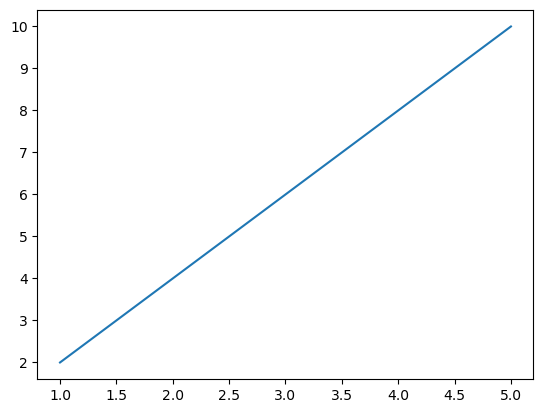

```python
x = [1,2,3,4,5]
y = [2,4,6,8,10]

plt.plot(x,y)
```

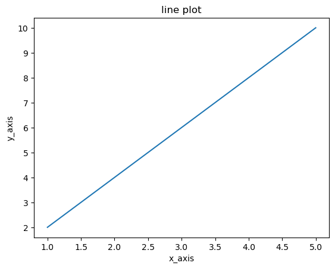

```python
plt.plot(x,y)
plt.title('line plot')
plt.xlabel('x_axis')
plt.ylabel('y_axis')
plt.show()
```

TYPES OF PLOTS

```
<BarContainer object of 5 artists>
```

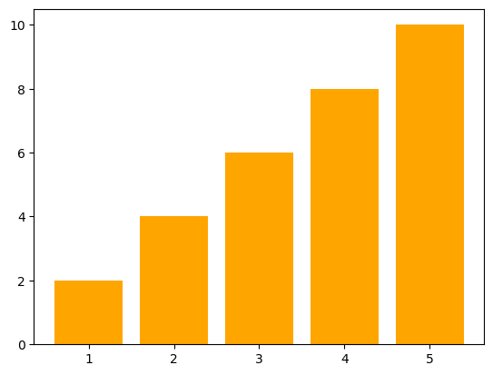

```python
plt.bar(x,y,color='orange') #barchart
```

```
<BarContainer object of 5 artists>
```

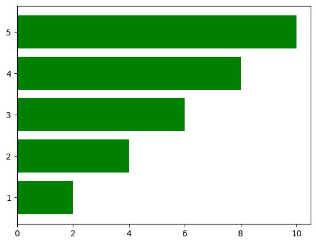

```python
plt.barh(x,y,color='green') #horizonatal bar
```

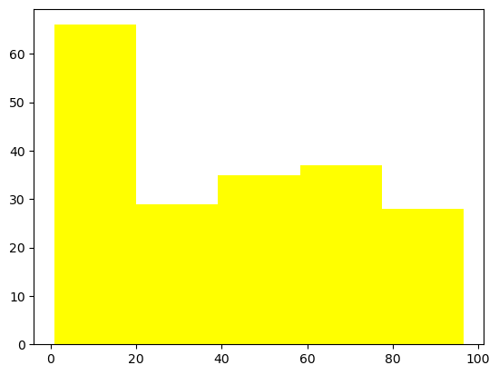

```python
plt.hist(df['InternetUsers'],bins=5,color='yellow') #histogram
```

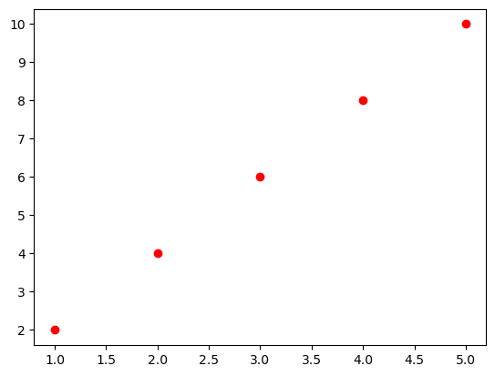

```python
plt.scatter(x,y,color='red')
```

```python
sample = df.head(4)
```

```python
sample
```

|  | CountryName | CountryCode | BirthRate | InternetUsers | IncomeGroup |
| --- | --- | --- | --- | --- | --- |
| 0 | Aruba | ABW | 10.244 | 30.0 | High income |
| 1 | Afghanistan | AFG | 35.253 | 5.9 | Low income |
| 2 | Angola | AGO | 45.985 | 19.1 | Upper middle income |
| 3 | Albania | ALB | 12.877 | 57.2 | Upper middle income |

[output not shown]

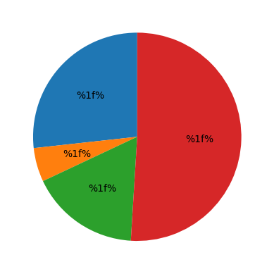

```python
plt.pie(sample['InternetUsers'], autopct='%%1f%%',startangle=90)
```

CUSTOMIZATION IN MATPLOTLIB

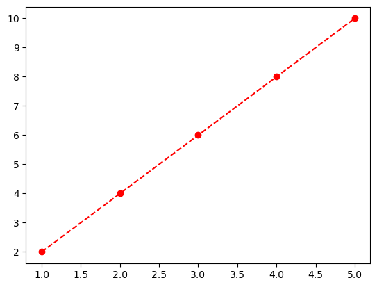

```python
plt.plot(x,y ,color='red',ls='--',marker='o')
```

SUBPLOT IN MATPLOTLIB

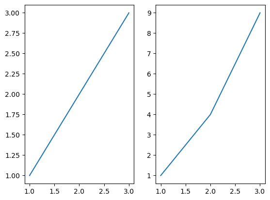

```python
plt.subplot(1,2,1)
plt.plot([1,2,3],[1,2,3])

plt.subplot(1,2,2)
plt.plot([1,2,3],[1,4,9])
```

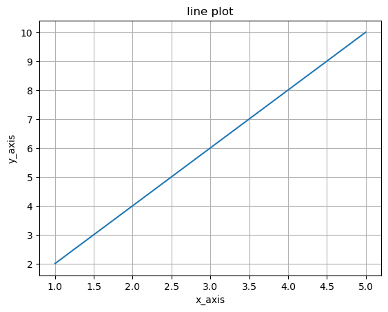

```python
plt.plot(x,y)
plt.title('line plot')
plt.xlabel('x_axis')
plt.ylabel('y_axis')
plt.grid(True)
```

SEABORN IN PYTHON

```python
import seaborn as sns
```

```python
sns.set_style('darkgrid')
```

TYPES OF PLOTS IN SEABORN

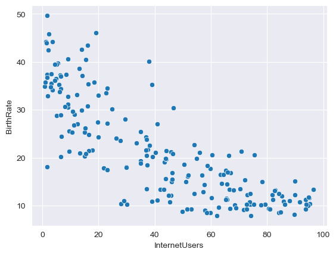

```python
sns.scatterplot(x='InternetUsers',y='BirthRate',data=df)
```

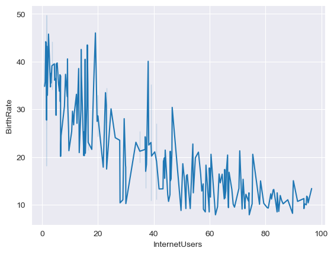

```python
sns.lineplot(x='InternetUsers',y='BirthRate',data=df)
```

DISTRIBUTION PLOT

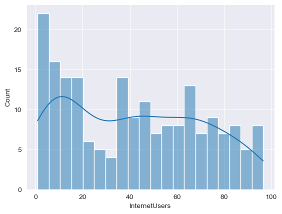

```python
sns.histplot(df['InternetUsers'],bins=20,kde= True)
```

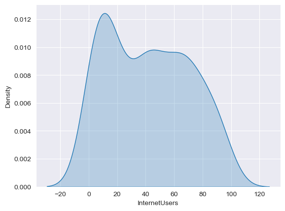

```python
sns.kdeplot(df['InternetUsers'],shade=True)
```

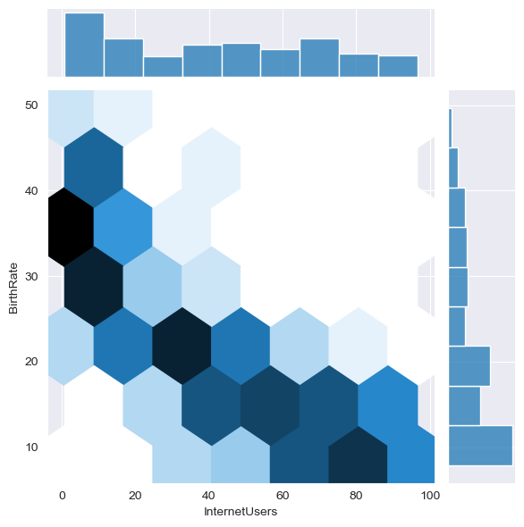

```python
sns.jointplot(x='InternetUsers',y='BirthRate',data=df,kind='hex')
```

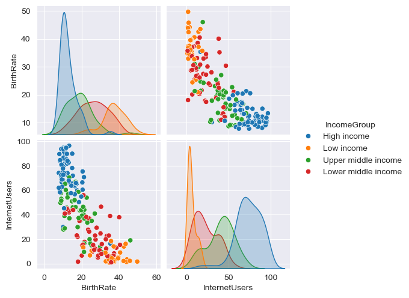

```python
sns.pairplot(df,hue='IncomeGroup')
```

CATEGORICAL PLOT IN SEABORN

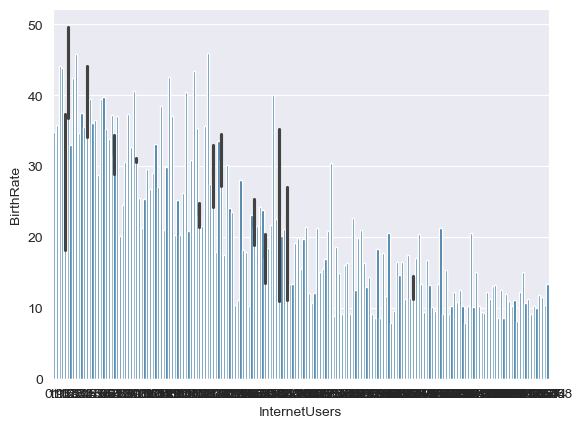

```python
sns.barplot(x='InternetUsers',y='BirthRate',data=df)
```

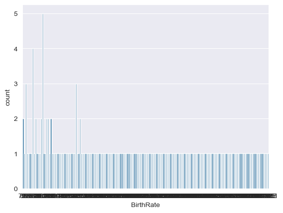

```python
sns.countplot(x='BirthRate',data=df)
```

BOX PLOT IN SEABORN

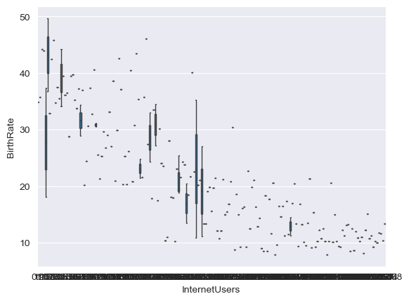

```python
sns.boxplot(x='InternetUsers',y='BirthRate',data=df)
```

VIOLIN PLOT IN SEABORN

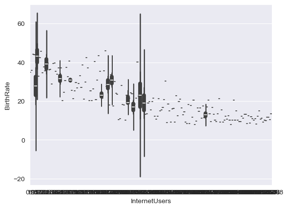

```python
sns.violinplot(x='InternetUsers',y='BirthRate',data=df)
```

STRIP/SWARM PLOT IN SEABORN

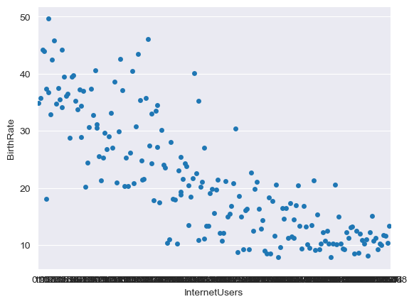

```python
sns.stripplot(x='InternetUsers',y='BirthRate',data=df,jitter=True)
```

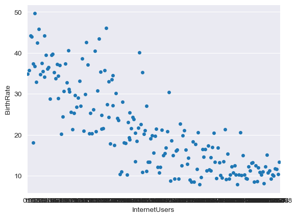

```python
sns.swarmplot(x='InternetUsers',y='BirthRate',data=df)
```